# Extracting Environmental Covariates for Movement Data

Briana Abrahms

September 10th 2019

```r
library(raster)
library(sf)
library(tidyverse)
library(knitr)
library(lubridate)
#devtools::install_github("ropensci/rerddap")
#devtools::install_github("rmendels/rerddapXtracto")
library(rerddap)
library(rerddapXtracto)
```

## Types of Spatial Data

Spatial data comes in two forms:

1. Vector data
2. Raster data

With important differences across classes.

### Vector Data

Vector models are a representation of the world using points, lines, and polygons. This class is useful for storing data that has discrete boundaries, such as country borders, land parcels, and roads. Often, vector data is stored as “shapefiles” (.shp).

### Raster Data

Raster models are a representation of the world as a surface divided into a regular grid of cells. Often, Rasters are stored as “GeoTIFFs” (.tif). .jpg, .png, and .gri/.grd are all other types of raster data files.

## Extracting from Vector Data

Let’s look at a zebra dataset and a road layer in Etosha National Park, Namibia.

```r
zebra <- read_csv("data_files/Zebra.csv") %>%
  dplyr::select(ID = Name, 4:6) %>%
  st_as_sf(., coords = 3:4, crs = "+init=epsg:4326") %>% #longlat
  st_transform("+init=epsg:32733") %>% #convert to UTM
  mutate(timestamp = as.POSIXct(lubridate::mdy_hm(Date)))

roads <- st_read("spatial_layers/enp roads.shp", crs = "+init=epsg:4326") %>%
  st_transform("+init=epsg:32733")
```

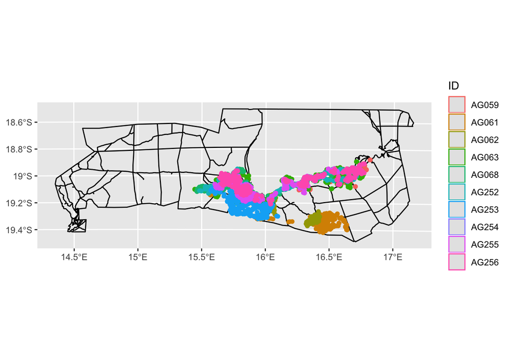

```r
ggplot() +
  geom_sf(data=roads) +
  geom_sf(data=zebra, aes(color=ID))
```

How close or far from different road types do zebra move? If we interogate our `roads` object a bit further, we see that there are several types of roads in the shapefile.

```r
head(roads)
```

```
## Simple feature collection with 6 features and 3 fields
## geometry type:  LINESTRING
## dimension:      XY
## bbox:           xmin: 444189.2 ymin: 7852892 xmax: 456895.4 ymax: 7862522
## epsg (SRID):    32733
## proj4string:    +proj=utm +zone=33 +south +datum=WGS84 +units=m +no_defs
##     TYPE LENGTH KM                       geometry
## 1  Track    0.7  1 LINESTRING (448015.3 785948...
## 2  Track    3.6  4 LINESTRING (446520.9 785873...
## 3 Graded    2.3  2 LINESTRING (446079.1 785289...
## 4  Track    7.1  7 LINESTRING (456408.4 786148...
## 5  Track    1.2  1 LINESTRING (456408.4 786148...
## 6 Graded    0.1  0 LINESTRING (450207.6 786205...
```

```r
unique(roads$TYPE)
```

```
## [1] Track  Graded Gravel Tar
## Levels: Graded Gravel Tar Track
```

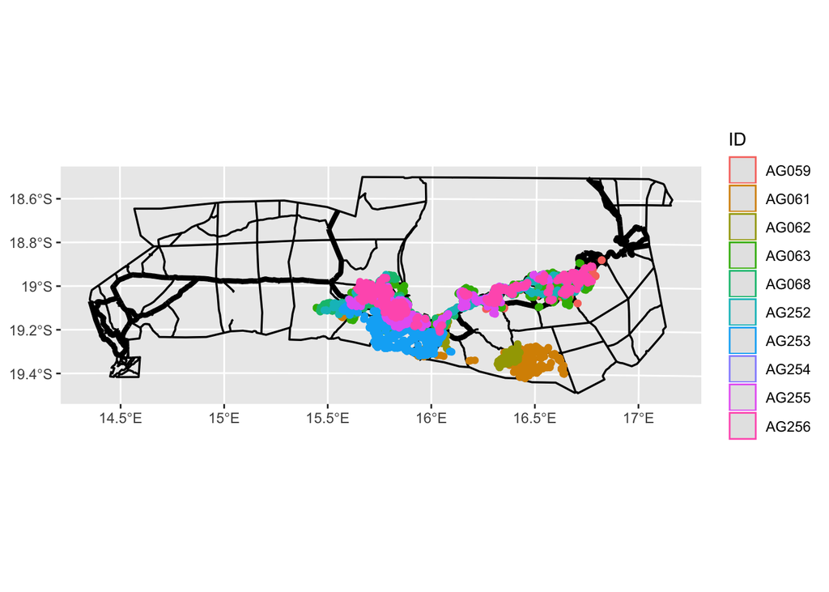

```r
large_roads <- filter(roads, TYPE %in% c("Tar", "Gravel"))
small_roads <- filter(roads, TYPE %in% c("Graded", "Track"))
ggplot() +
  geom_sf(data=large_roads, size=1.5) +
  geom_sf(data=small_roads, size=0.6) +
  geom_sf(data=zebra, aes(color=ID))
```

```r
# find the minimum distance (in meters) of each point to a large road
large_dist<- st_distance(y=zebra, x=large_roads) # a units matrix dim =[nrow(x), nrow(y)]; takes 10-20 seconds
zebra$large_road_dist <- apply(large_dist, 2, min)

# find the minimum distance (in meters) of each point to a small road
small_dist<- st_distance(y=zebra, x=small_roads) # a units matrix dim =[nrow(x), nrow(y)]; takes 10-20 seconds
zebra$small_road_dist <- apply(small_dist, 2, min)

head(data.frame(zebra))
```

```
##      ID          Date                 geometry           timestamp
## 1 AG059 4/20/09 15:40 POINT (594243.6 7885501) 2009-04-20 15:40:00
## 2 AG059 4/20/09 13:01   POINT (596576 7879266) 2009-04-20 13:01:00
## 3 AG059 4/20/09 12:02 POINT (596579.5 7879260) 2009-04-20 12:02:00
## 4 AG059 4/20/09 17:00   POINT (584733 7890124) 2009-04-20 17:00:00
## 5 AG059  4/21/09 1:40 POINT (596611.3 7879269) 2009-04-21 01:40:00
## 6 AG059  4/21/09 1:00 POINT (596605.8 7879266) 2009-04-21 01:00:00
##   large_road_dist small_road_dist
## 1        7.845860       3479.8987
## 2      163.187201        241.8660
## 3      156.746071        245.8446
## 4        9.115608       1605.2154
## 5      151.769751        227.9759
## 6      151.358102        231.6984
```

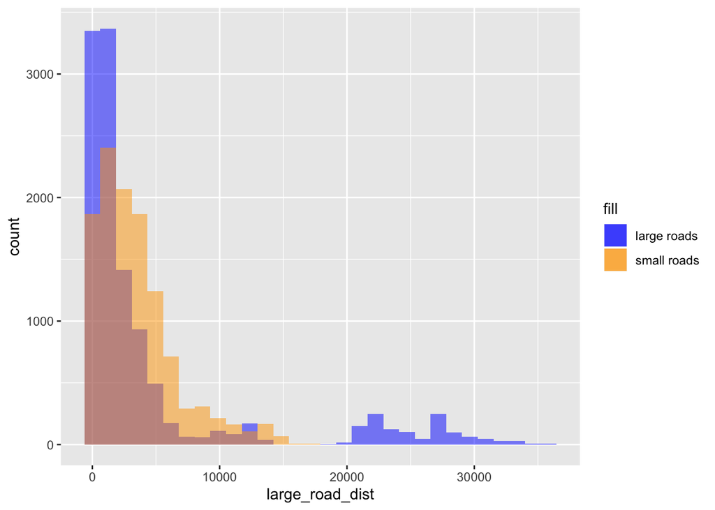

```r
ggplot(zebra) +
  geom_histogram(aes(large_road_dist, fill="large roads"), alpha=0.5) +
  geom_histogram(aes(small_road_dist, fill="small roads"), alpha=0.5) +
  scale_fill_manual(labels=c("large roads", "small roads"), values=c("blue", "orange"))
```

## Extracting from Raster Data

For raster data, the `raster` package works wonders for everything from simple extraction to complex raster calculations.

### Extracting from a single raster layer

Here we will extract the long-term average NDVI values 2000-2015 for each zebra location from a single raster layer.

```r
NDVI_mean <- raster("spatial_layers/ndvi_mean_utm.tif") * 0.0001

NDVI_mean
```

```
## class      : RasterLayer
## dimensions : 474, 1274, 603876  (nrow, ncol, ncell)
## resolution : 231.6564, 231.6564  (x, y)
## extent     : 431873.8, 727004, 7844489, 7954294  (xmin, xmax, ymin, ymax)
## crs        : +proj=utm +zone=33 +south +datum=WGS84 +units=m +no_defs +ellps=WGS84 +towgs84=0,0,0
## source     : memory
## names      : ndvi_mean_utm
## values     : -0.0558117, 0.5303021  (min, max)
```

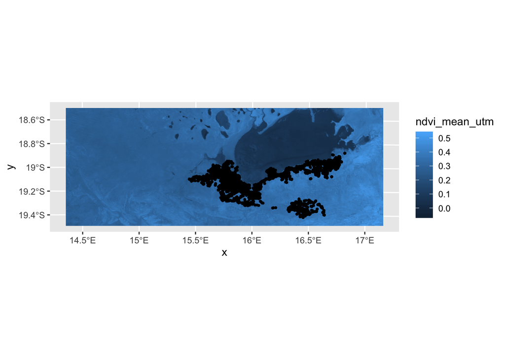

```r
NDVI_mean %>%
  rasterToPoints() %>%
  data.frame() %>%
  ggplot() + geom_raster(aes(x=x, y=y, fill=ndvi_mean_utm)) +
  geom_sf(data=zebra, size=0.7)
```

```r
zebra$NDVI_mean <- raster::extract(NDVI_mean, as(zebra, "Spatial"))

head(data.frame(zebra))
```

```
##      ID          Date                 geometry           timestamp
## 1 AG059 4/20/09 15:40 POINT (594243.6 7885501) 2009-04-20 15:40:00
## 2 AG059 4/20/09 13:01   POINT (596576 7879266) 2009-04-20 13:01:00
## 3 AG059 4/20/09 12:02 POINT (596579.5 7879260) 2009-04-20 12:02:00
## 4 AG059 4/20/09 17:00   POINT (584733 7890124) 2009-04-20 17:00:00
## 5 AG059  4/21/09 1:40 POINT (596611.3 7879269) 2009-04-21 01:40:00
## 6 AG059  4/21/09 1:00 POINT (596605.8 7879266) 2009-04-21 01:00:00
##   large_road_dist small_road_dist NDVI_mean
## 1        7.845860       3479.8987 0.2409661
## 2      163.187201        241.8660 0.2682169
## 3      156.746071        245.8446 0.2682169
## 4        9.115608       1605.2154 0.2380762
## 5      151.769751        227.9759 0.2419201
## 6      151.358102        231.6984 0.2419201
```

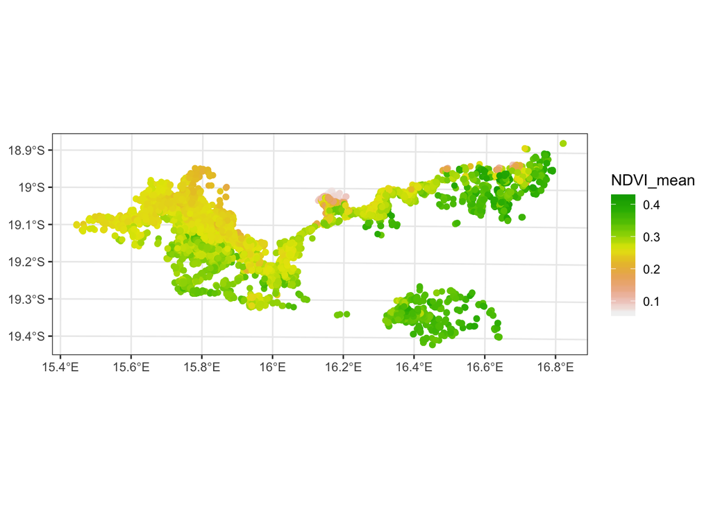

```r
ggplot(zebra) +
  geom_sf(aes(color=NDVI_mean)) +
  scale_color_gradientn(colors=rev(terrain.colors(10))) +
  theme_bw()
```

### Time-matching and extracting from a rasterstack

Many times we may have multiple raster layers within a single file, for example a layer for each day, month or year. In that case we load them as a `rasterstack` object and need to time-match them to extract the right value for the specific time of each data point. Here we will match zebra locations to 16-day NDVI layers. Please be advised the process of time-matching to rasters can take a long time.

```r
NDVI_stack <- stack("spatial_layers/modisV006_ndvi00_15_utm.tif")

NDVI_stack
```

```
## class      : RasterStack
## dimensions : 474, 1273, 603402, 365  (nrow, ncol, ncell, nlayers)
## resolution : 231.6564, 231.6564  (x, y)
## extent     : 432010, 726908.5, 7844455, 7954260  (xmin, xmax, ymin, ymax)
## crs        : +proj=utm +zone=33 +south +datum=WGS84 +units=m +no_defs +ellps=WGS84 +towgs84=0,0,0
## names      : modisV006_ndvi00_15_utm.1, modisV006_ndvi00_15_utm.2, modisV006_ndvi00_15_utm.3, modisV006_ndvi00_15_utm.4, modisV006_ndvi00_15_utm.5, modisV006_ndvi00_15_utm.6, modisV006_ndvi00_15_utm.7, modisV006_ndvi00_15_utm.8, modisV006_ndvi00_15_utm.9, modisV006_ndvi00_15_utm.10, modisV006_ndv…
```

```r
# often we know the date ranges of each layer, but in this case we have to get them
# from a reference file: these are named by year and yday
NDVI_stack_names <- read_csv("spatial_layers/names_modisV006ndvi_00_15_utm.csv")
year <- as.numeric(substr(NDVI_stack_names$x,5,8))
yday <- as.numeric(substr(NDVI_stack_names$x,9,11))
dates <- as.Date(yday, origin = paste(year,"01-01", sep="-"))

#assign time value (in this case year) to each layer
NDVI_stack <- setZ(NDVI_stack, dates)

NDVI_stack #note the new 'time' variable
```

```
## class      : RasterStack
## dimensions : 474, 1273, 603402, 365  (nrow, ncol, ncell, nlayers)
## resolution : 231.6564, 231.6564  (x, y)
## extent     : 432010, 726908.5, 7844455, 7954260  (xmin, xmax, ymin, ymax)
## crs        : +proj=utm +zone=33 +south +datum=WGS84 +units=m +no_defs +ellps=WGS84 +towgs84=0,0,0
## names      : modisV006_ndvi00_15_utm.1, modisV006_ndvi00_15_utm.2, modisV006_ndvi00_15_utm.3, modisV006_ndvi00_15_utm.4, modisV006_ndvi00_15_utm.5, modisV006_ndvi00_15_utm.6, modisV006_ndvi00_15_utm.7, modisV006_ndvi00_15_utm.8, modisV006_ndvi00_15_utm.9, modisV006_ndvi00_15_utm.10, modisV006_ndv…
## time        : 2000-02-19 - 2015-12-20 (range)
```

```r
#time match and extract
stack_dates <- getZ(NDVI_stack) #all raster layer dates
zebra$NDVI <- NA
for (i in 1:50) { #this would take a long time to run through nrow(zebra) locations, so demonstrating for first 50 locations
  #print(paste0("extracting zebra location #",i))
  zeb_date <- as.Date(zebra$timestamp[i])
  stack_idx <- which(stack_dates %in% seq(zeb_date - 15, zeb_date, by='day')) #which raster layer date matches zebra date
  zebra$NDVI[i] <-raster::extract(NDVI_stack[[stack_idx]], as(zebra$geometry[i], "Spatial")) #extract
}

head(data.frame(zebra))
```

```
##      ID          Date                 geometry           timestamp
## 1 AG059 4/20/09 15:40 POINT (594243.6 7885501) 2009-04-20 15:40:00
## 2 AG059 4/20/09 13:01   POINT (596576 7879266) 2009-04-20 13:01:00
## 3 AG059 4/20/09 12:02 POINT (596579.5 7879260) 2009-04-20 12:02:00
## 4 AG059 4/20/09 17:00   POINT (584733 7890124) 2009-04-20 17:00:00
## 5 AG059  4/21/09 1:40 POINT (596611.3 7879269) 2009-04-21 01:40:00
## 6 AG059  4/21/09 1:00 POINT (596605.8 7879266) 2009-04-21 01:00:00
##   large_road_dist small_road_dist NDVI_mean   NDVI
## 1        7.845860       3479.8987 0.2409661 0.2745
## 2      163.187201        241.8660 0.2682169 0.2865
## 3      156.746071        245.8446 0.2682169 0.2865
## 4        9.115608       1605.2154 0.2380762 0.2525
## 5      151.769751        227.9759 0.2419201 0.2865
## 6      151.358102        231.6984 0.2419201 0.2865
```

### Time-matching and extracting with Xtractomatic

A good resource for many environmental datasets, especially in the marine environment, are [NOAA’s ERDDAP gridded datasets](https://upwell.pfeg.noaa.gov/erddap/griddap/index.html?page=1&itemsPerPage=1000), which has hundreds of variables from temperature to chlorophyll to wind, and others. There is a handy R package called [Xtractomatic](https://coastwatch.pfeg.noaa.gov/xtracto/) which downloads and time-matches data from this server directly. Here we will use Xtractomatic to time-match locations for one albatross with 8-day chlorophyll values.

```r
#Load albatross and subset to one individual for demonstration's sake
albatross <- read_tsv("data_files/Study2911040", comment="##", col_types = "Tnncc") %>%
  as.data.frame() %>%
  na.omit()

albatross1 <- albatross %>% filter(individual_id=="2911059")

# The dataInfo call selects what dataset is chosen for the extraction
dataset <- 'erdMBchla8day_LonPM180' #8-day Aqua MODIS
(dataInfo <- rerddap::info(dataset))
```

```
## <ERDDAP info> erdMBchla8day_LonPM180
##  Base URL: https://upwell.pfeg.noaa.gov/erddap/
##  Dimensions (range):
##      time: (2005-12-29T00:00:00Z, 2019-08-30T00:00:00Z)
##      altitude: (0.0, 0.0)
##      latitude: (-45.0, 65.0)
##      longitude: (-180.0, 179.975)
##  Variables:
##      chlorophyll:
##          Units: mg m-3
```

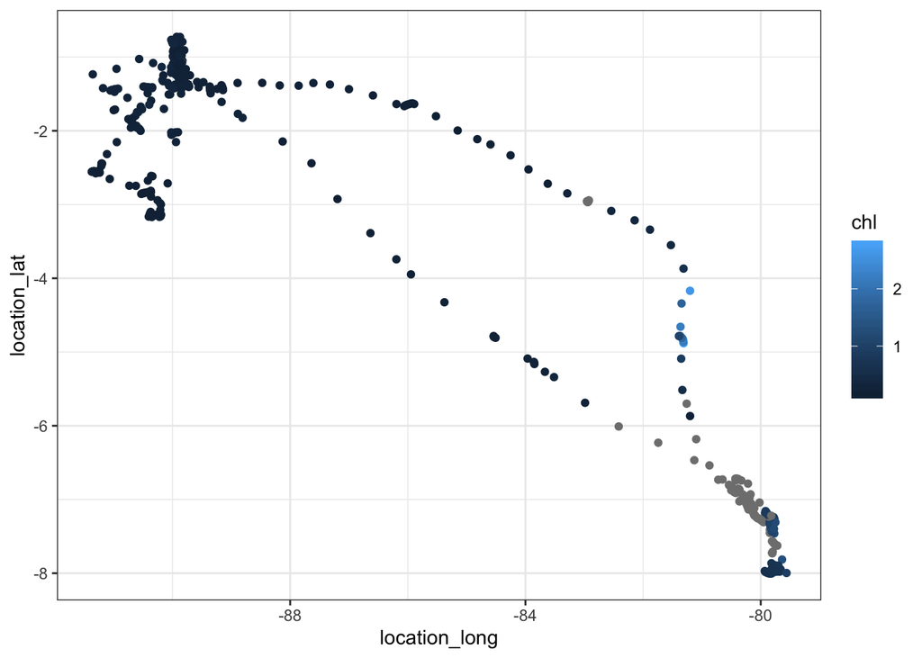

```r
# Depending on the dataset this may or may not have to be called.  Look at DataInfo to see if dataset has an altitude dimension.
# If it does, then the call to rxtracto must define zcoord, if it doesn't then the call should not give zcoord
# e.g. zcoords <- rep(0,nrow(albatross1))

# Now we will make the call to match up satellite data with the trackdata. Caution this can take several minutes to hours depending on the number of locations in your tracking dataset.
locs_chl <- rerddapXtracto::rxtracto(dataInfo,
                                      parameter = dataInfo$variable$variable_name, #chlorophyll
                                      xcoord=albatross1$location_long,
                                      ycoord=albatross1$location_lat,
                                      zcoord=rep(0,nrow(albatross1)), #set z coordinate to 0
                                      tcoord=as.Date(albatross1$timestamp), #must be in YYYY-MM-DD format
                                      xlen=0.1, ylen=0.1) #the search "radius" in the x and y directions, in degrees

# After it has completed the extraction the data.frame ‘locs_chl’ will contain as many
# datapoints as the location data and will have 11 columns:
#
# mean =              mean of data within search radius
# stdev =             standard deviation of data within search radius
# n =                 number of points found within search radius
# satellite date =    time of returned value
# requested lon min = min longitude of call (decimal degrees)
# requested lon max = max longitude of call (decimal degrees)
# requested lat min = min latitude of call (decimal degrees)
# requested lat max = max latitude of call (decimal degrees)
# requested date =    requested time in tag
# median =            median of data within search radius
# mad =               median absolute deviation of data within search radius

#Add extracted variable into tracking dataframe
albatross1$chl <- locs_chl$`mean chlorophyll`

ggplot(albatross1) +
  geom_point(aes(location_long, location_lat, color=chl)) +
  theme_bw()
```

Another feature of Xtractomatic is extracting environmental data within a pre-defined spatial boundary and time period, from which we can make time series. As an example, let’s extract the 8-day chlorophyll values within the extent of our albatross data.

```r
# Set spatial and temporal ranges
(xbounds<-c(min(albatross1$location_long), max(albatross1$location_long)))
```

```
## [1] -91.37320 -79.56111
```

```r
(ybounds<-c(min(albatross1$location_lat), max(albatross1$location_lat)))
```

```
## [1] -8.0052965 -0.7259347
```

```r
(timerange <- c(min(as.Date(albatross1$timestamp)), max(as.Date(albatross1$timestamp))))
```

```
## [1] "2008-05-31" "2008-07-17"
```

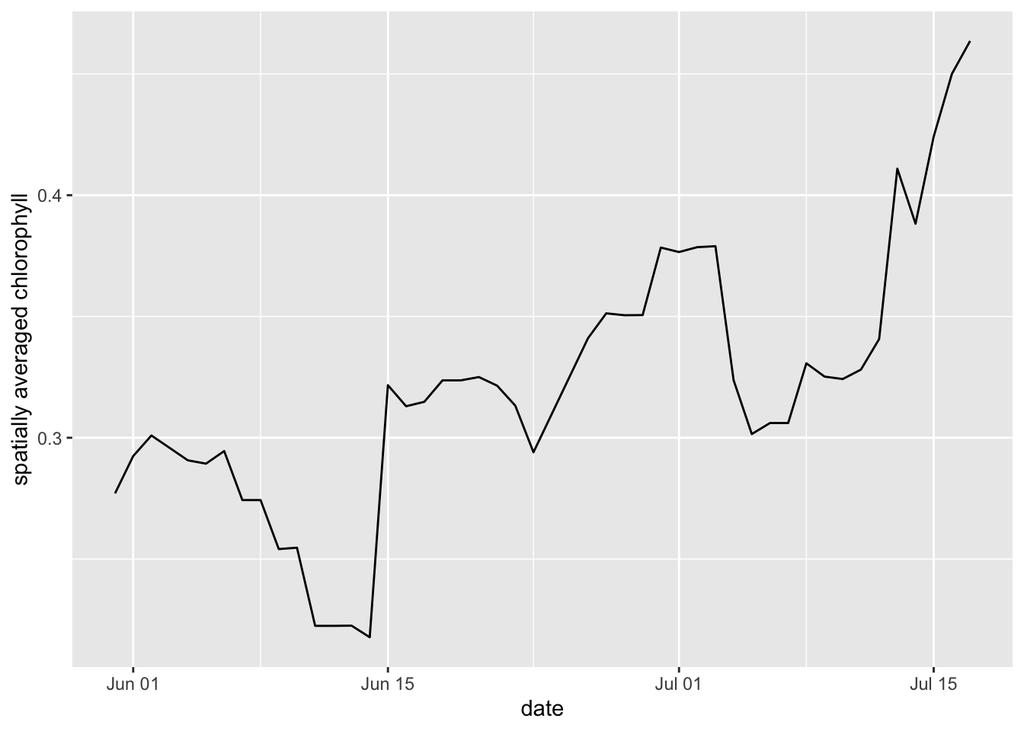

```r
#Extract
box_chl <- rxtracto_3D(dataInfo,
                        parameter=dataInfo$variable$variable_name, #chlorophyll
                        tcoord=timerange,
                        xcoord=xbounds,
                        ycoord=ybounds,
                        zcoord=rep(0,nrow(albatross1)))

# We can also spatially average across the data to plot a timeseries within the box
box_chl$chl_avg <- apply(box_chl$chlorophyll, c(4) , function(x) mean(x,na.rm=TRUE))

ggplot() + geom_line(aes(as.Date(box_chl$time), box_chl$chl_avg)) +
  xlab("date") + ylab("spatially averaged chlorophyll")
```

Check out the [Xtractomatic vignette](https://cran.r-project.org/web/packages/rerddapXtracto/vignettes/UsingrerddapXtracto.html) for more examples.

### A final note: Movebank annotation

For more environmental datasets, [Movebank.org](https://www.movebank.org) has an annotation service called [Env-DATA](https://www.movebank.org/node/6607) where you can upload your movement data privately and have a variety of environmental datasets time-matched to it directly. It usually takes 1-2 days for the service to complete. This is useful for annotating your tracking data, but you cannot download the environmental datasets from here directly (for example for raster calculation or plotting purposes).